# Week 1 In Class Notes

# Importing data

Read in .csv files with read_csv():

```r
csvPath <- here('data', 'milk_production.csv')
milk_production <- read_csv(csvPath)
```

Read in .txt files with read.table():

```r
txtPath <- here('data', 'nasa_global_temps.txt')
global_temps <- read.table(txtPath, skip = 5, header = FALSE)
# Rename the variables
names(global_temps) <- c('year', 'meanTemp', 'smoothTemp')
```

Read in .xlsx files with read_excel():

```r
library(readxl)
xlsxPath <- here('data', 'pv_cell_production.xlsx')
pv_cells <- read_excel(xlsxPath, sheet = 'Cell Prod by Country', skip = 2)
# Drop rows that don't contain data
pv_cells <- pv_cells %>%
    filter(is.na(Year) == FALSE, Year <= 2013)
```

# Importing data practice:

Write code to import the following files inside the “data” folder:

- wildlife_impacts.csv
- north_america_bear_killings.txt
- pc_sales_2018.xlsx

```r
wildlife_impacts <- read_csv(here('data', 'wildlife_impacts.csv'))

bear_killings <- read.table(
    here('data', 'north_america_bear_killings.txt'),
    header = TRUE)

pc_sales <- read_excel(here('data', 'pc_sales_2018.xlsx'),
                       sheet = 'pc_sales', skip = 5)
```

# Data provenance practice:

URLs to the original data sources:

- wildlife_impacts.csv: https://github.com/rfordatascience/tidytuesday/tree/master/data/2019/2019-07-23
- north_america_bear_killings.txt: https://data.world/makeovermonday/2019w21
- pc_sales_2018.xlsx: http://www.oica.net/category/sales-statistics/

Go to each of the above sites, then add the following information about the data to the “data_sources.txt” file:

- The name of the downloaded file in the “`data`” folder.
- The date you downloaded the file (i.e. today’s date).
- The url to the site you downloaded the data from.
- The source of the *original* data (if different from where you downloaded the data).
- A short description of the data and how they were collected.
- A dictionary for the data (if available).

### wildlife_impacts.csv:

The wildlife impact data is only from the big 4 airlines - 70% of the full database. Also, the data have been pre-processed.

### north_america_bear_killings.txt:

The source is Wikipedia and was hand-copied from by Ali Sanne.

### pc_sales_2018.xlsx:

The source is the International Organization of Motor Vehicle Manufacturers. Also, it only include passenger cars (not commercial vehicles).

# Tidy data

Read in data:

```r
library(readxl)
xlsxPath <- here('data', 'pv_cell_production.xlsx')
pv_cells <- read_excel(xlsxPath, sheet = 'Cell Prod by Country', skip = 2) %>%
    filter(is.na(Year) == FALSE, Year <= 2013)
```

Convert to “long” format (tidy):

```r
pv_cells_long <- pv_cells %>%
    gather(key = 'Country', value = 'nPVCells', China:World)
```

Convert to “wide” format (un-tidy):

```r
pv_cells_wide <- pv_cells_long %>%
    spread(key = Country, value = nPVCells)
```

# Tidy data practice 1: wide to long

1. Read in the `lotr_words.csv` data file.
2. Use `gather()` to “tidy” the data into four columns: Film, Race, Gender, Words.
3. Use `write_csv()` and `here()` to save your file at `lotr_words_tidy.csv` in the `data` folder.

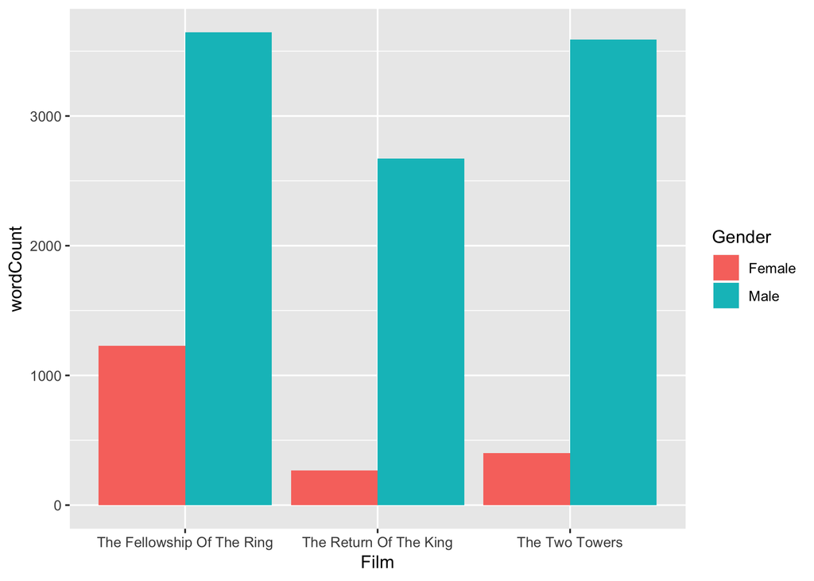

```r
lotr_words <- read_csv(here('data', 'lotr_words.csv'))
lotr_words_tidy <- lotr_words %>%
    gather(key = 'Gender', value = 'wordCount', Female:Male)

lotr_words_tidy %>%
    ggplot() +
    geom_col(aes(x = Film, y = wordCount, fill = Gender),
             position = 'dodge')
```

```r
    # Use geom_col instead of geom_bar so that you don't have to type
    # stat = 'identity'
```

# Tidy data practice 2: long to wide

1. Read in the `lotr_words_tidy.csv` data file.
2. Use `spread()` to convert the “tidy” data back into it’s untidy format with the columns: Film, Race, Female, Male.

```r
lotr_words_wide <- lotr_words_tidy %>%
    spread(key = Gender, value = wordCount)

lotr_words_wide %>%
    group_by(Film) %>%
    summarise(Female = sum(Female),
              Male = sum(Male)) %>%
    mutate(
        proportion = Female / (Female + Male),
        percent = round(100*proportion, 1))
```

```
## # A tibble: 3 x 5
##   Film                       Female  Male proportion percent
##   <chr>                       <dbl> <dbl>      <dbl>   <dbl>
## 1 The Fellowship Of The Ring   1243  6610     0.158     15.8
## 2 The Return Of The King        453  5642     0.0743     7.4
## 3 The Two Towers                732  6565     0.100     10
```